# Overview

Dataset info

| Number of variables | 41 |
| --- | --- |
| Number of observations | 65451 |
| Missing cells | 1211057 (45.1%) |
| Duplicate rows | 0 (0.0%) |
| Total size in memory | 128.0 MiB |
| Average record size in memory | 2.0 KiB |

Variables types

| UNSUPPORTED | 17 |
| --- | --- |
| CAT | 15 |
| BOOL | 4 |
| NUM | 3 |
| URL | 2 |

Toggle Reproduction Information

Reproduction info

| Date of analysis | 2020-02-13 21:53:53.078675 |
| --- | --- |
| Version | [pandas-profiling v2.4.0](https://github.com/pandas-profiling/pandas-profiling) |
| Command line | `pandas_profiling --config_file config.yaml [YOUR_FILE.csv]` |
| Download Configuration | config.yaml |

Toggle Warnings

Warnings

| `analysis_purpose_custom_custom` has 65451 (100.0%) missing values | Missing |
| --- | --- |
| `analysis_purpose_custom_custom` is an unsupported type, check if it needs cleaning or further analysis | Warning |
| `author` has a high cardinality: 45170 distinct values | Warning |
| `category_id2` has a high cardinality: 63 distinct values | Warning |
| `commentauthor` has 65451 (100.0%) missing values | Missing |
| `commentauthor` is an unsupported type, check if it needs cleaning or further analysis | Warning |
| `commentdatestring` has 65451 (100.0%) missing values | Missing |
| `commentdatestring` is an unsupported type, check if it needs cleaning or further analysis | Warning |
| `commenttext` has 65451 (100.0%) missing values | Missing |
| `commenttext` is an unsupported type, check if it needs cleaning or further analysis | Warning |
| `commentts` has 65451 (100.0%) missing values | Missing |
| `commentts` is an unsupported type, check if it needs cleaning or further analysis | Warning |
| `date` only contains datetime values, but is categorical. Consider applying `pd.to_datetime()` | Type |
| `date` has a high cardinality: 4152 distinct values | Warning |
| `flag_custom` has 65451 (100.0%) missing values | Missing |
| `flag_custom` is an unsupported type, check if it needs cleaning or further analysis | Warning |
| `helpfulcount` has 65451 (100.0%) missing values | Missing |
| `helpfulcount` is an unsupported type, check if it needs cleaning or further analysis | Warning |
| `id` has a high cardinality: 961 distinct values | Warning |
| `inputtime` only contains datetime values, but is categorical. Consider applying `pd.to_datetime()` | Type |
| `inputtime` has a high cardinality: 29402 distinct values | Warning |
| `name` has a high cardinality: 1032 distinct values | Warning |
| `notes` has 65451 (100.0%) missing values | Missing |
| `notes` is an unsupported type, check if it needs cleaning or further analysis | Warning |
| `officialcomment` has 65451 (100.0%) missing values | Missing |
| `officialcomment` is an unsupported type, check if it needs cleaning or further analysis | Warning |
| `parent` has a high cardinality: 696 distinct values | Warning |
| `PART_NUMBER_custom` has 65451 (100.0%) missing values | Missing |
| `PART_NUMBER_custom` is an unsupported type, check if it needs cleaning or further analysis | Warning |
| `product` has a high cardinality: 961 distinct values | Warning |
| `profile` has 33264 (50.8%) missing values | Missing |
| `pvotes` is highly skewed (γ1 = 83.37762533) | Skewed |
| `pvotes` has 57943 (88.5%) zeros | Zeros |
| `reviewid` has a high cardinality: 65382 distinct values | Warning |
| `sentiment` has constant value "Not Assigned" | Rejected |
| `SKU_custom` has 65451 (100.0%) missing values | Missing |
| `SKU_custom` is an unsupported type, check if it needs cleaning or further analysis | Warning |
| `special_name_custom` has 65451 (100.0%) missing values | Missing |
| `special_name_custom` is an unsupported type, check if it needs cleaning or further analysis | Warning |
| `status` has constant value "Not Assigned" | Rejected |
| `statusdt` has 65451 (100.0%) missing values | Missing |
| `statusdt` is an unsupported type, check if it needs cleaning or further analysis | Warning |
| `statustime` has 65451 (100.0%) missing values | Missing |
| `statustime` is an unsupported type, check if it needs cleaning or further analysis | Warning |
| `test_field2_custom` has 65451 (100.0%) missing values | Missing |
| `test_field2_custom` is an unsupported type, check if it needs cleaning or further analysis | Warning |
| `test_field3_custom` has 65451 (100.0%) missing values | Missing |
| `test_field3_custom` is an unsupported type, check if it needs cleaning or further analysis | Warning |
| `text` has a high cardinality: 62304 distinct values | Warning |
| `title` has a high cardinality: 43166 distinct values | Warning |
| `topic` has constant value "Not Assigned" | Rejected |
| `totalcomments` has 65451 (100.0%) missing values | Missing |
| `totalcomments` is an unsupported type, check if it needs cleaning or further analysis | Warning |
| `tvotes` is highly skewed (γ1 = 80.44402789) | Skewed |
| `tvotes` has 57473 (87.8%) zeros | Zeros |
| `vine` has 64666 (98.8%) missing values | Missing |
| `tvotes` is highly correlated with `pvotes` | High Correlation |
| `pvotes` is highly correlated with `tvotes` | High Correlation |
| `status` is highly correlated with `sentiment` and 1 other fields | High Correlation |
| `sentiment` is highly correlated with `status` and 1 other fields | High Correlation |
| `topic` is highly correlated with `sentiment` and 1 other fields | High Correlation |

# Variables

analysis_purpose_custom_custom  
Unsupported

`MISSING`  
`UNSUPPORTED`

| Missing | 65451 |
| --- | --- |
| Missing (%) | 100.0% |
| Memory size | 1022.7 KiB |

author  
Categorical

`HIGH CARDINALITY`

| Distinct count | 45170 |
| --- | --- |
| Unique (%) | 69.0% |
| Missing | 133 |
| Missing (%) | 0.2% |
| Memory size | 1022.7 KiB |

| Amazon Customer | 6270 |
| --- | --- |
| Client d'Amazon | 734 |
| Amazon Kunde | 411 |
| Kindle Customer | 158 |
| Chris | 77 |
| Other values (45164) | 57668 |

Toggle details

**Common Values**

| Value | Count | Frequency (%) |  |
| --- | --- | --- | --- |
| Amazon Customer | 6270 | 9.6% |  |
| Client d'Amazon | 734 | 1.1% |  |
| Amazon Kunde | 411 | 0.6% |  |
| Kindle Customer | 158 | 0.2% |  |
| Chris | 77 | 0.1% |  |
| Sarah | 73 | 0.1% |  |
| Mike | 61 | 0.1% |  |
| Jennifer | 60 | 0.1% |  |
| Lisa | 58 | 0.1% |  |
| Michelle | 53 | 0.1% |  |
| Other values (45159) | 57363 | 87.6% |  |
| (Missing) | 133 | 0.2% |  |

**Composition**

Composition

| Contains chars | True |
| --- | --- |
| Contains digits | True |
| Contains whitespace | True |
| Contains non-words | True |

Length

| Max length | 96 |
| --- | --- |
| Mean length | 10.24624528 |
| Min length | 1 |

**Length**

[figure not shown]

category_id2  
Categorical

`HIGH CARDINALITY`

| Distinct count | 63 |
| --- | --- |
| Unique (%) | 0.1% |
| Missing | 317 |
| Missing (%) | 0.5% |
| Memory size | 1022.7 KiB |

| pet-supplies | 40702 |
| --- | --- |
| pet-supplies/2975420011 | 4351 |
| pet-supplies/470699031 | 2868 |
| ce-de/3578331 | 2798 |
| pet-supplies/2975425011 | 1820 |
| Other values (57) | 12595 |

Toggle details

**Common Values**

| Value | Count | Frequency (%) |  |
| --- | --- | --- | --- |
| pet-supplies | 40702 | 62.2% |  |
| pet-supplies/2975420011 | 4351 | 6.6% |  |
| pet-supplies/470699031 | 2868 | 4.4% |  |
| ce-de/3578331 | 2798 | 4.3% |  |
| pet-supplies/2975425011 | 1820 | 2.8% |  |
| pet-supplies/3024230011 | 1500 | 2.3% |  |
| pet-supplies/2975259011 | 1306 | 2.0% |  |
| pet-supplies/471393031 | 1298 | 2.0% |  |
| pet-supplies/470792031 | 909 | 1.4% |  |
| pet-supplies/6292263011 | 528 | 0.8% |  |
| Other values (52) | 7054 | 10.8% |  |

**Composition**

Composition

| Contains chars | True |
| --- | --- |
| Contains digits | True |
| Contains whitespace | False |
| Contains non-words | True |

Length

| Max length | 24 |
| --- | --- |
| Mean length | 15.45719699 |
| Min length | 3 |

**Length**

[figure not shown]

commentauthor  
Unsupported

`MISSING`  
`UNSUPPORTED`

| Missing | 65451 |
| --- | --- |
| Missing (%) | 100.0% |
| Memory size | 1022.7 KiB |

commentdatestring  
Unsupported

`MISSING`  
`UNSUPPORTED`

| Missing | 65451 |
| --- | --- |
| Missing (%) | 100.0% |
| Memory size | 1022.7 KiB |

commenttext  
Unsupported

`MISSING`  
`UNSUPPORTED`

| Missing | 65451 |
| --- | --- |
| Missing (%) | 100.0% |
| Memory size | 1022.7 KiB |

commentts  
Unsupported

`MISSING`  
`UNSUPPORTED`

| Missing | 65451 |
| --- | --- |
| Missing (%) | 100.0% |
| Memory size | 1022.7 KiB |

date  
Categorical

`TYPE DATE`  
`HIGH CARDINALITY`

| Distinct count | 4152 |
| --- | --- |
| Unique (%) | 6.3% |
| Missing | 0 |
| Missing (%) | 0.0% |
| Memory size | 1022.7 KiB |

| 2017-04-24 08:00 | 119 |
| --- | --- |
| 2017-07-18 08:00 | 86 |
| 2017-12-04 08:00 | 82 |
| 2016-02-03 08:00 | 66 |
| 2019-12-11 08:00 | 59 |
| Other values (4147) | 65039 |

Toggle details

**Common Values**

| Value | Count | Frequency (%) |  |
| --- | --- | --- | --- |
| 2017-04-24 08:00 | 119 | 0.2% |  |
| 2017-07-18 08:00 | 86 | 0.1% |  |
| 2017-12-04 08:00 | 82 | 0.1% |  |
| 2016-02-03 08:00 | 66 | 0.1% |  |
| 2019-12-11 08:00 | 59 | 0.1% |  |
| 2016-03-09 08:00 | 57 | 0.1% |  |
| 2019-11-03 08:00 | 57 | 0.1% |  |
| 2019-05-15 08:00 | 56 | 0.1% |  |
| 2016-12-01 08:00 | 56 | 0.1% |  |
| 2019-12-29 08:00 | 55 | 0.1% |  |
| Other values (4142) | 64758 | 98.9% |  |

**Composition**

Composition

| Contains chars | False |
| --- | --- |
| Contains digits | True |
| Contains whitespace | True |
| Contains non-words | True |

Length

| Max length | 16 |
| --- | --- |
| Mean length | 16 |
| Min length | 16 |

**Length**

[figure not shown]

flag_custom  
Unsupported

`MISSING`  
`UNSUPPORTED`

| Missing | 65451 |
| --- | --- |
| Missing (%) | 100.0% |
| Memory size | 1022.7 KiB |

helpfulcount  
Unsupported

`MISSING`  
`UNSUPPORTED`

| Missing | 65451 |
| --- | --- |
| Missing (%) | 100.0% |
| Memory size | 1022.7 KiB |

id  
Categorical

`HIGH CARDINALITY`

| Distinct count | 961 |
| --- | --- |
| Unique (%) | 1.5% |
| Missing | 0 |
| Missing (%) | 0.0% |
| Memory size | 1022.7 KiB |

| B00063446M | 6351 |
| --- | --- |
| B0009811TW | 2798 |
| B00VIXRB6O | 2657 |
| B00173CWDW | 2391 |
| B00074L4W2 | 2338 |
| Other values (956) | 48916 |

Toggle details

**Common Values**

| Value | Count | Frequency (%) |  |
| --- | --- | --- | --- |
| B00063446M | 6351 | 9.7% |  |
| B0009811TW | 2798 | 4.3% |  |
| B00VIXRB6O | 2657 | 4.1% |  |
| B00173CWDW | 2391 | 3.7% |  |
| B00074L4W2 | 2338 | 3.6% |  |
| B004488VQ4 | 1610 | 2.5% |  |
| B0721735K9 | 1463 | 2.2% |  |
| B000241NRI | 1298 | 2.0% |  |
| B00074L4RW | 1295 | 2.0% |  |
| B00063496C | 1237 | 1.9% |  |
| Other values (951) | 42013 | 64.2% |  |

**Composition**

Composition

| Contains chars | True |
| --- | --- |
| Contains digits | True |
| Contains whitespace | False |
| Contains non-words | False |

Length

| Max length | 10 |
| --- | --- |
| Mean length | 10 |
| Min length | 10 |

**Length**

[figure not shown]

image  
Boolean

| Distinct count | 2 |
| --- | --- |
| Unique (%) | < 0.1% |
| Missing | 0 |
| Missing (%) | 0.0% |
| Memory size | 1022.7 KiB |

| No | 64245 |
| --- | --- |
| Yes | 1206 |

Toggle details

**Frequency Table**

| Value | Count | Frequency (%) |  |
| --- | --- | --- | --- |
| No | 64245 | 98.2% |  |
| Yes | 1206 | 1.8% |  |

inputtime  
Categorical

`TYPE DATE`  
`HIGH CARDINALITY`

| Distinct count | 29402 |
| --- | --- |
| Unique (%) | 44.9% |
| Missing | 0 |
| Missing (%) | 0.0% |
| Memory size | 1022.7 KiB |

| 2016-02-03 08:00 | 66 |
| --- | --- |
| 2016-03-09 08:00 | 57 |
| 2016-12-01 08:00 | 56 |
| 2016-01-16 08:00 | 54 |
| 2015-12-03 08:00 | 53 |
| Other values (29397) | 65165 |

Toggle details

**Common Values**

| Value | Count | Frequency (%) |  |
| --- | --- | --- | --- |
| 2016-02-03 08:00 | 66 | 0.1% |  |
| 2016-03-09 08:00 | 57 | 0.1% |  |
| 2016-12-01 08:00 | 56 | 0.1% |  |
| 2016-01-16 08:00 | 54 | 0.1% |  |
| 2015-12-03 08:00 | 53 | 0.1% |  |
| 2016-02-22 08:00 | 53 | 0.1% |  |
| 2016-12-29 08:00 | 52 | 0.1% |  |
| 2017-01-05 08:00 | 51 | 0.1% |  |
| 2016-12-30 08:00 | 51 | 0.1% |  |
| 2015-07-30 08:00 | 50 | 0.1% |  |
| Other values (29392) | 64908 | 99.2% |  |

**Composition**

Composition

| Contains chars | False |
| --- | --- |
| Contains digits | True |
| Contains whitespace | True |
| Contains non-words | True |

Length

| Max length | 16 |
| --- | --- |
| Mean length | 16 |
| Min length | 16 |

**Length**

[figure not shown]

name  
Categorical

`HIGH CARDINALITY`

| Distinct count | 1032 |
| --- | --- |
| Unique (%) | 1.6% |
| Missing | 0 |
| Missing (%) | 0.0% |
| Memory size | 3.5 MiB |

| PetSafe Drinkwell Cat and Dog Water Fountain - Butterfly or Original Pet Drinking Fountain - Best for Cats and Small Dogs | 6446 |
| --- | --- |
| PetSafe Gentle Leader Headcollar, No-Pull Dog Collar | 4825 |
| SportDOG Rechargeable Bark Control Collar | 2391 |
| PetSafe Healthy Pet Simply Feed Automatic Cat and Dog Feeder with Stainless Steel Bowl, Holds Dry Cat and Dog Food | 2380 |
| PetSafe RFA-67 6 Volt Replacement Batteries | 2211 |
| Other values (1027) | 47198 |

Toggle details

**Common Values**

| Value | Count | Frequency (%) |  |
| --- | --- | --- | --- |
| PetSafe Drinkwell Cat and Dog Water Fountain - Butterfly or Original Pet Drinking Fountain - Best for Cats and Small Dogs | 6446 | 9.8% |  |
| PetSafe Gentle Leader Headcollar, No-Pull Dog Collar | 4825 | 7.4% |  |
| SportDOG Rechargeable Bark Control Collar | 2391 | 3.7% |  |
| PetSafe Healthy Pet Simply Feed Automatic Cat and Dog Feeder with Stainless Steel Bowl, Holds Dry Cat and Dog Food | 2380 | 3.6% |  |
| PetSafe RFA-67 6 Volt Replacement Batteries | 2211 | 3.4% |  |
| PetSafe Yard & Park Rechargeable Dog Training Collar with Tone and Static Correction, Waterproof, Up to 400 Yards | 1610 | 2.5% |  |
| PetSafe SSSCAT Spray Pet Deterrent, Motion Activated Pet Proofing Repellent for Cats and Dogs | 1463 | 2.2% |  |
| PetSafe Automatic 2 Meal Cat and Dog Feeder - Cat and Dog Food Dispenser - Battery Powered | 1220 | 1.9% |  |
| PetSafe Drinkwell Replacement Carbon Filters, Dog and Cat Water Fountain Filters | 1141 | 1.7% |  |
| PetSafe Staywell 4 Way Locking Classic Cat Flap, Tunnel included, Easy Install, Durable, Pet Door for Cats | 768 | 1.2% |  |
| Other values (1022) | 40996 | 62.6% |  |

**Composition**

Composition

| Contains chars | True |
| --- | --- |
| Contains digits | True |
| Contains whitespace | True |
| Contains non-words | True |

Length

| Max length | 220 |
| --- | --- |
| Mean length | 83.22522192 |
| Min length | 14 |

**Length**

[figure not shown]

notes  
Unsupported

`MISSING`  
`UNSUPPORTED`

| Missing | 65451 |
| --- | --- |
| Missing (%) | 100.0% |
| Memory size | 1022.7 KiB |

officialcomment  
Unsupported

`MISSING`  
`UNSUPPORTED`

| Missing | 65451 |
| --- | --- |
| Missing (%) | 100.0% |
| Memory size | 1022.7 KiB |

parent  
Categorical

`HIGH CARDINALITY`

| Distinct count | 696 |
| --- | --- |
| Unique (%) | 1.1% |
| Missing | 0 |
| Missing (%) | 0.0% |
| Memory size | 1022.7 KiB |

| B081W769S4 | 6446 |
| --- | --- |
| B07XTY7FR9 | 4825 |
| B011S9AAI8 | 2391 |
| B0798DW18H | 2380 |
| B01KZTB3HE | 2211 |
| Other values (691) | 47198 |

Toggle details

**Common Values**

| Value | Count | Frequency (%) |  |
| --- | --- | --- | --- |
| B081W769S4 | 6446 | 9.8% |  |
| B07XTY7FR9 | 4825 | 7.4% |  |
| B011S9AAI8 | 2391 | 3.7% |  |
| B0798DW18H | 2380 | 3.6% |  |
| B01KZTB3HE | 2211 | 3.4% |  |
| B004488VQ4 | 1610 | 2.5% |  |
| B073QT2PFQ | 1463 | 2.2% |  |
| B000241NRI | 1266 | 1.9% |  |
| B06XKBPMX7 | 1141 | 1.7% |  |
| B00FQKS5VK | 1037 | 1.6% |  |
| Other values (686) | 40681 | 62.2% |  |

**Composition**

Composition

| Contains chars | True |
| --- | --- |
| Contains digits | True |
| Contains whitespace | False |
| Contains non-words | False |

Length

| Max length | 10 |
| --- | --- |
| Mean length | 10 |
| Min length | 10 |

**Length**

[figure not shown]

PART_NUMBER_custom  
Unsupported

`MISSING`  
`UNSUPPORTED`

| Missing | 65451 |
| --- | --- |
| Missing (%) | 100.0% |
| Memory size | 1022.7 KiB |

product  
Categorical

`HIGH CARDINALITY`

| Distinct count | 961 |
| --- | --- |
| Unique (%) | 1.5% |
| Missing | 0 |
| Missing (%) | 0.0% |
| Memory size | 1022.7 KiB |

| B00063446M | 6351 |
| --- | --- |
| B0009811TW | 2798 |
| B00VIXRB6O | 2657 |
| B00173CWDW | 2391 |
| B00074L4W2 | 2338 |
| Other values (956) | 48916 |

Toggle details

**Common Values**

| Value | Count | Frequency (%) |  |
| --- | --- | --- | --- |
| B00063446M | 6351 | 9.7% |  |
| B0009811TW | 2798 | 4.3% |  |
| B00VIXRB6O | 2657 | 4.1% |  |
| B00173CWDW | 2391 | 3.7% |  |
| B00074L4W2 | 2338 | 3.6% |  |
| B004488VQ4 | 1610 | 2.5% |  |
| B0721735K9 | 1463 | 2.2% |  |
| B000241NRI | 1298 | 2.0% |  |
| B00074L4RW | 1295 | 2.0% |  |
| B00063496C | 1237 | 1.9% |  |
| Other values (951) | 42013 | 64.2% |  |

**Composition**

Composition

| Contains chars | True |
| --- | --- |
| Contains digits | True |
| Contains whitespace | False |
| Contains non-words | False |

Length

| Max length | 10 |
| --- | --- |
| Mean length | 10 |
| Min length | 10 |

**Length**

[figure not shown]

profile  
URL

`MISSING`

| Distinct count | 30641 |
| --- | --- |
| Unique (%) | 46.8% |
| Missing | 33264 |
| Missing (%) | 50.8% |
| Memory size | 1022.7 KiB |

| https://www.amazon.de/gp/profile/amzn1.account.AEFZNPOYVG3HRDUZLC6GNYO37Y7Q | 7 |
| --- | --- |
| https://www.amazon.fr/gp/profile/amzn1.account.AHKMAG5Y5DJ3IMJGK3KRHBUDXAHA | 7 |
| https://www.amazon.ca/gp/profile/amzn1.account.AFHK7X5ZHGSCZZ5WDMCZ6E74IKQA/ref=cm_cr_arp_d_gw_btm?ie=UTF8 | 6 |
| https://www.amazon.de/gp/profile/amzn1.account.AHSG62PGZDRYBGJCXEDUDR5NZ77Q/ref=cm_cr_arp_d_pdp?ie=UTF8 | 6 |
| https://www.amazon.co.uk/gp/pdp/profile/A1DZX0I6BL1EH2/ref=cm_cr_arp_d_pdp?ie=UTF8 | 6 |
| Other values (30635) | 32155 |
| (Missing) | 33264 |

Toggle details

**Full**

| Value | Count | Frequency (%) |  |
| --- | --- | --- | --- |
| https://www.amazon.de/gp/profile/amzn1.account.AEFZNPOYVG3HRDUZLC6GNYO37Y7Q | 7 | < 0.1% |  |
| https://www.amazon.fr/gp/profile/amzn1.account.AHKMAG5Y5DJ3IMJGK3KRHBUDXAHA | 7 | < 0.1% |  |
| https://www.amazon.ca/gp/profile/amzn1.account.AFHK7X5ZHGSCZZ5WDMCZ6E74IKQA/ref=cm_cr_arp_d_gw_btm?ie=UTF8 | 6 | < 0.1% |  |
| https://www.amazon.de/gp/profile/amzn1.account.AHSG62PGZDRYBGJCXEDUDR5NZ77Q/ref=cm_cr_arp_d_pdp?ie=UTF8 | 6 | < 0.1% |  |
| https://www.amazon.co.uk/gp/pdp/profile/A1DZX0I6BL1EH2/ref=cm_cr_arp_d_pdp?ie=UTF8 | 6 | < 0.1% |  |
| https://www.amazon.ca/gp/profile/amzn1.account.AEBZNXT6U2OSJNVXD3YQSGTACQOQ/ref=cm_cr_arp_d_pdp?ie=UTF8 | 5 | < 0.1% |  |
| https://www.amazon.ca/gp/profile/amzn1.account.AHCHWCORVXYKZGKLMRCJZWNMYTLA/ref=cm_cr_arp_d_pdp?ie=UTF8 | 5 | < 0.1% |  |
| https://www.amazon.de/gp/profile/amzn1.account.AFDQ6KXDEM4YCII3362IQX7T2U3A/ref=cm_cr_arp_d_pdp?ie=UTF8 | 5 | < 0.1% |  |
| https://www.amazon.de/gp/profile/amzn1.account.AGPO4IBBZWMIXM7ZEU4PQDAB6IMA/ref=cm_cr_arp_d_pdp?ie=UTF8 | 5 | < 0.1% |  |
| https://www.amazon.de/gp/profile/amzn1.account.AF7CVCZZIAUFPPGPFUR5KAN5UWGA/ref=cm_cr_arp_d_pdp?ie=UTF8 | 5 | < 0.1% |  |
| Other values (30630) | 32130 | 49.1% |  |
| (Missing) | 33264 | 50.8% |  |

**Scheme**

| Value | Count | Frequency (%) |  |
| --- | --- | --- | --- |
| https | 32187 | 49.2% |  |
| (Missing) | 33264 | 50.8% |  |

**Netloc**

| Value | Count | Frequency (%) |  |
| --- | --- | --- | --- |
| www.amazon.com | 11460 | 17.5% |  |
| www.amazon.ca | 9373 | 14.3% |  |
| www.amazon.co.uk | 5558 | 8.5% |  |
| www.amazon.fr | 3214 | 4.9% |  |
| www.amazon.de | 2582 | 3.9% |  |
| (Missing) | 33264 | 50.8% |  |

**Path**

| Value | Count | Frequency (%) |  |
| --- | --- | --- | --- |
| /gp/profile/amzn1.account.AHKMAG5Y5DJ3IMJGK3KRHBUDXAHA | 7 | < 0.1% |  |
| /gp/profile/amzn1.account.AEFZNPOYVG3HRDUZLC6GNYO37Y7Q | 7 | < 0.1% |  |
| /gp/profile/amzn1.account.AHSG62PGZDRYBGJCXEDUDR5NZ77Q/ref=cm_cr_arp_d_pdp | 6 | < 0.1% |  |
| /gp/profile/amzn1.account.AFHK7X5ZHGSCZZ5WDMCZ6E74IKQA/ref=cm_cr_arp_d_gw_btm | 6 | < 0.1% |  |
| /gp/pdp/profile/A1DZX0I6BL1EH2/ref=cm_cr_arp_d_pdp | 6 | < 0.1% |  |
| /gp/profile/amzn1.account.AGU4BFVGZTZVD7DI7BLAPZX55Q6Q/ref=cm_cr_arp_d_pdp | 6 | < 0.1% |  |
| /gp/profile/amzn1.account.AEK7X2ANFVN3GQCDSF6ADXOHCXZA/ref=cm_cr_arp_d_pdp | 5 | < 0.1% |  |
| /gp/profile/amzn1.account.AFDQ6KXDEM4YCII3362IQX7T2U3A/ref=cm_cr_arp_d_pdp | 5 | < 0.1% |  |
| /gp/profile/amzn1.account.AEBZNXT6U2OSJNVXD3YQSGTACQOQ/ref=cm_cr_arp_d_pdp | 5 | < 0.1% |  |
| /gp/profile/amzn1.account.AFANETDZWA76SRQNMADSOVRHDO2Q/ref=cm_cr_arp_d_pdp | 5 | < 0.1% |  |
| Other values (30628) | 32129 | 49.1% |  |
| (Missing) | 33264 | 50.8% |  |

**Query**

| Value | Count | Frequency (%) |  |
| --- | --- | --- | --- |
| ie=UTF8 | 23141 | 35.4% |  |
|  | 9046 | 13.8% |  |
| (Missing) | 33264 | 50.8% |  |

**Fragment**

| Value | Count | Frequency (%) |  |
| --- | --- | --- | --- |
|  | 32187 | 49.2% |  |
| (Missing) | 33264 | 50.8% |  |

pvotes  
Real number (ℝ<sub>≥0</sub>)

`SKEWED`  
`ZEROS`  
`HIGH CORRELATION`

| Distinct count | 113 |
| --- | --- |
| Unique (%) | 0.2% |
| Missing | 0 |
| Missing (%) | 0.0% |
| Infinite | 0 |
| Infinite (%) | 0.0% |

| Mean | 0.5482421965 |
| --- | --- |
| Minimum | 0 |
| Maximum | 1422 |
| Zeros | 57943 |
| Zeros (%) | 88.5% |
| Memory size | 1022.7 KiB |

[figure not shown]

Toggle details

**Statistics**

Quantile statistics

| Minimum | 0 |
| --- | --- |
| 5-th percentile | 0 |
| Q1 | 0 |
| median | 0 |
| Q3 | 0 |
| 95-th percentile | 2 |
| Maximum | 1422 |
| Range | 1422 |
| Interquartile range (IQR) | 0 |

Descriptive statistics

| Standard deviation | 10.00120881 |
| --- | --- |
| Coefficient of variation (CV) | 18.24231858 |
| Kurtosis | 9352.403936 |
| Mean | 0.5482421965 |
| Median Absolute Deviation (MAD) | 0.9707047284 |
| Skewness | 83.37762533 |
| Sum | 35883 |
| Variance | 100.0241776 |

**Histogram(s)**

**Histogram**

[figure not shown]

**Histogram with fixed size bins** (bins=10)

**Dynamic Histogram**

[figure not shown]

**Histogram with variable size bins** (bins=[0.000e+00 5.000e-01 1.500e+00 2.500e+00 3.500e+00 ... 3.450e+01 4.750e+01 1.015e+02 3.970e+02 1.422e+03], ["bayesian blocks"](https://ui.adsabs.harvard.edu/abs/2013ApJ...764..167S/abstract) binning strategy used)

**Common values**

| Value | Count | Frequency (%) |  |
| --- | --- | --- | --- |
| 0 | 57943 | 88.5% |  |
| 1 | 4180 | 6.4% |  |
| 2 | 1260 | 1.9% |  |
| 3 | 626 | 1.0% |  |
| 4 | 329 | 0.5% |  |
| 5 | 217 | 0.3% |  |
| 6 | 153 | 0.2% |  |
| 7 | 100 | 0.2% |  |
| 8 | 75 | 0.1% |  |
| 9 | 58 | 0.1% |  |
| Other values (103) | 510 | 0.8% |  |

**Extreme values**

**Minimum 5 values**

| Value | Count | Frequency (%) |  |
| --- | --- | --- | --- |
| 0 | 57943 | 88.5% |  |
| 1 | 4180 | 6.4% |  |
| 2 | 1260 | 1.9% |  |
| 3 | 626 | 1.0% |  |
| 4 | 329 | 0.5% |  |

**Maximum 5 values**

| Value | Count | Frequency (%) |  |
| --- | --- | --- | --- |
| 1422 | 1 | < 0.1% |  |
| 1059 | 1 | < 0.1% |  |
| 801 | 1 | < 0.1% |  |
| 601 | 1 | < 0.1% |  |
| 547 | 1 | < 0.1% |  |

reviewid  
Categorical

`HIGH CARDINALITY`

| Distinct count | 65382 |
| --- | --- |
| Unique (%) | 99.9% |
| Missing | 0 |
| Missing (%) | 0.0% |
| Memory size | 1022.7 KiB |

| R38YLJS0MLZMMT | 3 |
| --- | --- |
| R1B32F0G6CHTTM | 3 |
| RK6EQ6BWPXA14 | 3 |
| R2K5MOU7D3WOEO | 3 |
| R28YF3QT4OUP13 | 3 |
| Other values (65377) | 65436 |

Toggle details

**Common Values**

| Value | Count | Frequency (%) |  |
| --- | --- | --- | --- |
| R38YLJS0MLZMMT | 3 | < 0.1% |  |
| R1B32F0G6CHTTM | 3 | < 0.1% |  |
| RK6EQ6BWPXA14 | 3 | < 0.1% |  |
| R2K5MOU7D3WOEO | 3 | < 0.1% |  |
| R28YF3QT4OUP13 | 3 | < 0.1% |  |
| R12QOLGUY57HZF | 2 | < 0.1% |  |
| RBSTNPF4UQJPG | 2 | < 0.1% |  |
| RW4B1HXFLND1H | 2 | < 0.1% |  |
| RIYNV46K6TTIS | 2 | < 0.1% |  |
| R2D86K7TOQRIMU | 2 | < 0.1% |  |
| Other values (65372) | 65426 | > 99.9% |  |

**Composition**

Composition

| Contains chars | True |
| --- | --- |
| Contains digits | True |
| Contains whitespace | False |
| Contains non-words | False |

Length

| Max length | 14 |
| --- | --- |
| Mean length | 13.7361996 |
| Min length | 11 |

**Length**

[figure not shown]

reviewlink  
URL

`UNIQUE`

| Distinct count | 65451 |
| --- | --- |
| Unique (%) | 100.0% |
| Missing | 0 |
| Missing (%) | 0.0% |
| Memory size | 3.5 MiB |

| https://www.amazon.com/review/RTJFRXPLHWQEJ/ref=cm_cr_dp_title?ie=UTF8&ASIN=B00062F6HE | 1 |
| --- | --- |
| https://www.amazon.ca/review/R1UR4Q2C91NMK0/ref=cm_cr_dp_title?ie=UTF8&ASIN=B0011EZQ5I | 1 |
| https://www.amazon.com/review/R2YBH7IDU70RJ7/ref=cm_cr_dp_title?ie=UTF8&ASIN=B001943LAW | 1 |
| https://www.amazon.com/review/RLAL6XHTBPWAW/ref=cm_cr_dp_title?ie=UTF8&ASIN=B00652WSLQ | 1 |
| https://www.amazon.ca/review/R2IWTFD25Y44NC/ref=cm_cr_dp_title?ie=UTF8&ASIN=B004UORHXK | 1 |
| Other values (65446) | 65446 |

Toggle details

**Full**

| Value | Count | Frequency (%) |  |
| --- | --- | --- | --- |
| https://www.amazon.com/review/RTJFRXPLHWQEJ/ref=cm_cr_dp_title?ie=UTF8&ASIN=B00062F6HE | 1 | < 0.1% |  |
| https://www.amazon.ca/review/R1UR4Q2C91NMK0/ref=cm_cr_dp_title?ie=UTF8&ASIN=B0011EZQ5I | 1 | < 0.1% |  |
| https://www.amazon.com/review/R2YBH7IDU70RJ7/ref=cm_cr_dp_title?ie=UTF8&ASIN=B001943LAW | 1 | < 0.1% |  |
| https://www.amazon.com/review/RLAL6XHTBPWAW/ref=cm_cr_dp_title?ie=UTF8&ASIN=B00652WSLQ | 1 | < 0.1% |  |
| https://www.amazon.ca/review/R2IWTFD25Y44NC/ref=cm_cr_dp_title?ie=UTF8&ASIN=B004UORHXK | 1 | < 0.1% |  |
| https://www.amazon.com/review/R1XUQHPDVL2CKL/ref=cm_cr_dp_title?ie=UTF8&ASIN=B00VIXRB6O | 1 | < 0.1% |  |
| https://www.amazon.co.uk/review/R3B3V85290YHJE/ref=cm_cr_dp_title?ie=UTF8&ASIN=B00F0JF9GQ | 1 | < 0.1% |  |
| https://www.amazon.com/review/R3UHURJGM0YQU5/ref=cm_cr_dp_title?ie=UTF8&ASIN=B00063446M | 1 | < 0.1% |  |
| https://www.amazon.co.uk/review/R3BWX2PZG08SE9/ref=cm_cr_dp_title?ie=UTF8&ASIN=B00B17ETPI | 1 | < 0.1% |  |
| https://www.amazon.com/review/R1U3BVOOL9IBXX/ref=cm_cr_dp_title?ie=UTF8&ASIN=B0721735K9 | 1 | < 0.1% |  |
| Other values (65441) | 65441 | > 99.9% |  |

**Scheme**

| Value | Count | Frequency (%) |  |
| --- | --- | --- | --- |
| https | 65451 | 100.0% |  |

**Netloc**

| Value | Count | Frequency (%) |  |
| --- | --- | --- | --- |
| www.amazon.com | 32101 | 49.0% |  |
| www.amazon.ca | 14528 | 22.2% |  |
| www.amazon.co.uk | 10244 | 15.7% |  |
| www.amazon.de | 4587 | 7.0% |  |
| www.amazon.fr | 3991 | 6.1% |  |

**Path**

| Value | Count | Frequency (%) |  |
| --- | --- | --- | --- |
| /review/R28YF3QT4OUP13/ref=cm_cr_dp_title | 3 | < 0.1% |  |
| /review/R2K5MOU7D3WOEO/ref=cm_cr_dp_title | 3 | < 0.1% |  |
| /review/R1B32F0G6CHTTM/ref=cm_cr_dp_title | 3 | < 0.1% |  |
| /review/R38YLJS0MLZMMT/ref=cm_cr_dp_title | 3 | < 0.1% |  |
| /review/RK6EQ6BWPXA14/ref=cm_cr_dp_title | 3 | < 0.1% |  |
| /review/R1TJD80A9KNZEZ/ref=cm_cr_dp_title | 2 | < 0.1% |  |
| /review/R1ZZARQZ0VST16/ref=cm_cr_dp_title | 2 | < 0.1% |  |
| /review/R3AWIDW3DIE18E/ref=cm_cr_dp_title | 2 | < 0.1% |  |
| /review/R18JA2FIQX5NEL/ref=cm_cr_dp_title | 2 | < 0.1% |  |
| /review/R2WY1CODPN8E2R/ref=cm_cr_dp_title | 2 | < 0.1% |  |
| Other values (65372) | 65426 | > 99.9% |  |

**Query**

| Value | Count | Frequency (%) |  |
| --- | --- | --- | --- |
| ie=UTF8&ASIN=B00063446M | 6351 | 9.7% |  |
| ie=UTF8&ASIN=B0009811TW | 2798 | 4.3% |  |
| ie=UTF8&ASIN=B00VIXRB6O | 2657 | 4.1% |  |
| ie=UTF8&ASIN=B00173CWDW | 2391 | 3.7% |  |
| ie=UTF8&ASIN=B00074L4W2 | 2338 | 3.6% |  |
| ie=UTF8&ASIN=B004488VQ4 | 1610 | 2.5% |  |
| ie=UTF8&ASIN=B0721735K9 | 1463 | 2.2% |  |
| ie=UTF8&ASIN=B000241NRI | 1298 | 2.0% |  |
| ie=UTF8&ASIN=B00074L4RW | 1295 | 2.0% |  |
| ie=UTF8&ASIN=B00063496C | 1237 | 1.9% |  |
| Other values (951) | 42013 | 64.2% |  |

**Fragment**

| Value | Count | Frequency (%) |  |
| --- | --- | --- | --- |
|  | 65451 | 100.0% |  |

sentiment  
Categorical

`CONST`  
`HIGH CORRELATION`

| Distinct count | 1 |
| --- | --- |
| Unique (%) | < 0.1% |
| Missing | 0 |
| Missing (%) | 0.0% |
| Memory size | 3.5 MiB |

| Not Assigned | 65451 |
| --- | --- |

Toggle details

**Common Values**

| Value | Count | Frequency (%) |  |
| --- | --- | --- | --- |
| Not Assigned | 65451 | 100.0% |  |

**Composition**

Composition

| Contains chars | True |
| --- | --- |
| Contains digits | False |
| Contains whitespace | True |
| Contains non-words | True |

Length

| Max length | 12 |
| --- | --- |
| Mean length | 12 |
| Min length | 12 |

**Length**

[figure not shown]

SKU_custom  
Unsupported

`MISSING`  
`UNSUPPORTED`

| Missing | 65451 |
| --- | --- |
| Missing (%) | 100.0% |
| Memory size | 1022.7 KiB |

source  
Categorical

| Distinct count | 5 |
| --- | --- |
| Unique (%) | < 0.1% |
| Missing | 0 |
| Missing (%) | 0.0% |
| Memory size | 1022.7 KiB |

| amazon | 32101 |
| --- | --- |
| amazon.ca | 14528 |
| amazon.uk | 10244 |
| amazon.de | 4587 |
| amazon.fr | 3991 |

Toggle details

**Common Values**

| Value | Count | Frequency (%) |  |
| --- | --- | --- | --- |
| amazon | 32101 | 49.0% |  |
| amazon.ca | 14528 | 22.2% |  |
| amazon.uk | 10244 | 15.7% |  |
| amazon.de | 4587 | 7.0% |  |
| amazon.fr | 3991 | 6.1% |  |

**Composition**

Composition

| Contains chars | True |
| --- | --- |
| Contains digits | False |
| Contains whitespace | False |
| Contains non-words | True |

Length

| Max length | 9 |
| --- | --- |
| Mean length | 7.528624467 |
| Min length | 6 |

**Length**

[figure not shown]

special_name_custom  
Unsupported

`MISSING`  
`UNSUPPORTED`

| Missing | 65451 |
| --- | --- |
| Missing (%) | 100.0% |
| Memory size | 1022.7 KiB |

stars  
Real number (ℝ<sub>≥0</sub>)

| Distinct count | 5 |
| --- | --- |
| Unique (%) | < 0.1% |
| Missing | 0 |
| Missing (%) | 0.0% |
| Infinite | 0 |
| Infinite (%) | 0.0% |

| Mean | 3.977769629 |
| --- | --- |
| Minimum | 1 |
| Maximum | 5 |
| Zeros | 0 |
| Zeros (%) | 0.0% |
| Memory size | 1022.7 KiB |

[figure not shown]

Toggle details

**Statistics**

Quantile statistics

| Minimum | 1 |
| --- | --- |
| 5-th percentile | 1 |
| Q1 | 3 |
| median | 5 |
| Q3 | 5 |
| 95-th percentile | 5 |
| Maximum | 5 |
| Range | 4 |
| Interquartile range (IQR) | 2 |

Descriptive statistics

| Standard deviation | 1.415566923 |
| --- | --- |
| Coefficient of variation (CV) | 0.3558695086 |
| Kurtosis | -0.2170625988 |
| Mean | 3.977769629 |
| Median Absolute Deviation (MAD) | 1.15903522 |
| Skewness | -1.119403272 |
| Sum | 260349 |
| Variance | 2.003829714 |

**Histogram(s)**

**Histogram**

[figure not shown]

**Histogram with fixed size bins** (bins=10)

**Common values**

| Value | Count | Frequency (%) |  |
| --- | --- | --- | --- |
| 5 | 36880 | 56.3% |  |
| 4 | 10353 | 15.8% |  |
| 1 | 7867 | 12.0% |  |
| 3 | 5968 | 9.1% |  |
| 2 | 4383 | 6.7% |  |

**Extreme values**

**Minimum 5 values**

| Value | Count | Frequency (%) |  |
| --- | --- | --- | --- |
| 1 | 7867 | 12.0% |  |
| 2 | 4383 | 6.7% |  |
| 3 | 5968 | 9.1% |  |
| 4 | 10353 | 15.8% |  |
| 5 | 36880 | 56.3% |  |

**Maximum 5 values**

| Value | Count | Frequency (%) |  |
| --- | --- | --- | --- |
| 5 | 36880 | 56.3% |  |
| 4 | 10353 | 15.8% |  |
| 3 | 5968 | 9.1% |  |
| 2 | 4383 | 6.7% |  |
| 1 | 7867 | 12.0% |  |

status  
Categorical

`CONST`  
`HIGH CORRELATION`

| Distinct count | 1 |
| --- | --- |
| Unique (%) | < 0.1% |
| Missing | 0 |
| Missing (%) | 0.0% |
| Memory size | 3.5 MiB |

| Not Assigned | 65451 |
| --- | --- |

Toggle details

**Common Values**

| Value | Count | Frequency (%) |  |
| --- | --- | --- | --- |
| Not Assigned | 65451 | 100.0% |  |

**Composition**

Composition

| Contains chars | True |
| --- | --- |
| Contains digits | False |
| Contains whitespace | True |
| Contains non-words | True |

Length

| Max length | 12 |
| --- | --- |
| Mean length | 12 |
| Min length | 12 |

**Length**

[figure not shown]

statusdt  
Unsupported

`MISSING`  
`UNSUPPORTED`

| Missing | 65451 |
| --- | --- |
| Missing (%) | 100.0% |
| Memory size | 3.5 MiB |

statustime  
Unsupported

`MISSING`  
`UNSUPPORTED`

| Missing | 65451 |
| --- | --- |
| Missing (%) | 100.0% |
| Memory size | 3.5 MiB |

test_field2_custom  
Unsupported

`MISSING`  
`UNSUPPORTED`

| Missing | 65451 |
| --- | --- |
| Missing (%) | 100.0% |
| Memory size | 3.5 MiB |

test_field3_custom  
Unsupported

`MISSING`  
`UNSUPPORTED`

| Missing | 65451 |
| --- | --- |
| Missing (%) | 100.0% |
| Memory size | 3.5 MiB |

text  
Categorical

`HIGH CARDINALITY`

| Distinct count | 62304 |
| --- | --- |
| Unique (%) | 95.2% |
| Missing | 5 |
| Missing (%) | < 0.1% |
| Memory size | 3.5 MiB |

| Good | 134 |
| --- | --- |
| Great | 108 |
| Perfect | 83 |
| Works great | 79 |
| good | 75 |
| Other values (62298) | 64967 |

Toggle details

**Common Values**

| Value | Count | Frequency (%) |  |
| --- | --- | --- | --- |
| Good | 134 | 0.2% |  |
| Great | 108 | 0.2% |  |
| Perfect | 83 | 0.1% |  |
| Works great | 79 | 0.1% |  |
| good | 75 | 0.1% |  |
| Great product | 74 | 0.1% |  |
| great | 71 | 0.1% |  |
| Excellent | 66 | 0.1% |  |
| Works great! | 56 | 0.1% |  |
| works great | 48 | 0.1% |  |
| Other values (62293) | 64652 | 98.8% |  |

**Composition**

Composition

| Contains chars | True |
| --- | --- |
| Contains digits | True |
| Contains whitespace | True |
| Contains non-words | True |

Length

| Max length | 12893 |
| --- | --- |
| Mean length | 299.9857451 |
| Min length | 1 |

**Length**

[figure not shown]

title  
Categorical

`HIGH CARDINALITY`

| Distinct count | 43166 |
| --- | --- |
| Unique (%) | 66.0% |
| Missing | 5 |
| Missing (%) | < 0.1% |
| Memory size | 3.5 MiB |

| Five Stars | 6637 |
| --- | --- |
| Four Stars | 1447 |
| Three Stars | 704 |
| One Star | 689 |
| Two Stars | 437 |
| Other values (43160) | 55532 |

Toggle details

**Common Values**

| Value | Count | Frequency (%) |  |
| --- | --- | --- | --- |
| Five Stars | 6637 | 10.1% |  |
| Four Stars | 1447 | 2.2% |  |
| Three Stars | 704 | 1.1% |  |
| One Star | 689 | 1.1% |  |
| Two Stars | 437 | 0.7% |  |
| Great product | 310 | 0.5% |  |
| Great | 245 | 0.4% |  |
| Good product | 174 | 0.3% |  |
| Good | 174 | 0.3% |  |
| Works great | 162 | 0.2% |  |
| Other values (43155) | 54467 | 83.2% |  |

**Composition**

Composition

| Contains chars | True |
| --- | --- |
| Contains digits | True |
| Contains whitespace | True |
| Contains non-words | True |

Length

| Max length | 223 |
| --- | --- |
| Mean length | 24.78470917 |
| Min length | 1 |

**Length**

[figure not shown]

topic  
Categorical

`CONST`  
`HIGH CORRELATION`

| Distinct count | 1 |
| --- | --- |
| Unique (%) | < 0.1% |
| Missing | 0 |
| Missing (%) | 0.0% |
| Memory size | 3.5 MiB |

| Not Assigned | 65451 |
| --- | --- |

Toggle details

**Common Values**

| Value | Count | Frequency (%) |  |
| --- | --- | --- | --- |
| Not Assigned | 65451 | 100.0% |  |

**Composition**

Composition

| Contains chars | True |
| --- | --- |
| Contains digits | False |
| Contains whitespace | True |
| Contains non-words | True |

Length

| Max length | 12 |
| --- | --- |
| Mean length | 12 |
| Min length | 12 |

**Length**

[figure not shown]

totalcomments  
Unsupported

`MISSING`  
`UNSUPPORTED`

| Missing | 65451 |
| --- | --- |
| Missing (%) | 100.0% |
| Memory size | 3.5 MiB |

tvotes  
Real number (ℝ<sub>≥0</sub>)

`SKEWED`  
`ZEROS`  
`HIGH CORRELATION`

| Distinct count | 116 |
| --- | --- |
| Unique (%) | 0.2% |
| Missing | 0 |
| Missing (%) | 0.0% |
| Infinite | 0 |
| Infinite (%) | 0.0% |

| Mean | 0.5932682465 |
| --- | --- |
| Minimum | 0 |
| Maximum | 1441 |
| Zeros | 57473 |
| Zeros (%) | 87.8% |
| Memory size | 3.5 MiB |

[figure not shown]

Toggle details

**Statistics**

Quantile statistics

| Minimum | 0 |
| --- | --- |
| 5-th percentile | 0 |
| Q1 | 0 |
| median | 0 |
| Q3 | 0 |
| 95-th percentile | 2 |
| Maximum | 1441 |
| Range | 1441 |
| Interquartile range (IQR) | 0 |

Descriptive statistics

| Standard deviation | 10.37427137 |
| --- | --- |
| Coefficient of variation (CV) | 17.48664526 |
| Kurtosis | 8737.968023 |
| Mean | 0.5932682465 |
| Median Absolute Deviation (MAD) | 1.04190634 |
| Skewness | 80.44402789 |
| Sum | 38830 |
| Variance | 107.6255064 |

**Histogram(s)**

**Histogram**

[figure not shown]

**Histogram with fixed size bins** (bins=10)

**Dynamic Histogram**

[figure not shown]

**Histogram with variable size bins** (bins=[0.000e+00 5.000e-01 1.500e+00 2.500e+00 3.500e+00 ... 3.350e+01 5.250e+01 1.035e+02 4.140e+02 1.441e+03], ["bayesian blocks"](https://ui.adsabs.harvard.edu/abs/2013ApJ...764..167S/abstract) binning strategy used)

**Common values**

| Value | Count | Frequency (%) |  |
| --- | --- | --- | --- |
| 0 | 57473 | 87.8% |  |
| 1 | 4320 | 6.6% |  |
| 2 | 1361 | 2.1% |  |
| 3 | 696 | 1.1% |  |
| 4 | 368 | 0.6% |  |
| 5 | 240 | 0.4% |  |
| 6 | 170 | 0.3% |  |
| 7 | 111 | 0.2% |  |
| 8 | 91 | 0.1% |  |
| 10 | 64 | 0.1% |  |
| Other values (106) | 557 | 0.9% |  |

**Extreme values**

**Minimum 5 values**

| Value | Count | Frequency (%) |  |
| --- | --- | --- | --- |
| 0 | 57473 | 87.8% |  |
| 1 | 4320 | 6.6% |  |
| 2 | 1361 | 2.1% |  |
| 3 | 696 | 1.1% |  |
| 4 | 368 | 0.6% |  |

**Maximum 5 values**

| Value | Count | Frequency (%) |  |
| --- | --- | --- | --- |
| 1441 | 1 | < 0.1% |  |
| 1078 | 1 | < 0.1% |  |
| 855 | 1 | < 0.1% |  |
| 629 | 1 | < 0.1% |  |
| 547 | 1 | < 0.1% |  |

verified  
Boolean

| Distinct count | 2 |
| --- | --- |
| Unique (%) | < 0.1% |
| Missing | 0 |
| Missing (%) | 0.0% |
| Memory size | 3.1 MiB |

| True | 59264 |
| --- | --- |
| False | 6187 |

Toggle details

**Frequency Table**

| Value | Count | Frequency (%) |  |
| --- | --- | --- | --- |
| True | 59264 | 90.5% |  |
| False | 6187 | 9.5% |  |

video  
Boolean

| Distinct count | 2 |
| --- | --- |
| Unique (%) | < 0.1% |
| Missing | 0 |
| Missing (%) | 0.0% |
| Memory size | 3.5 MiB |

| No | 65330 |
| --- | --- |
| Yes | 121 |

Toggle details

**Frequency Table**

| Value | Count | Frequency (%) |  |
| --- | --- | --- | --- |
| No | 65330 | 99.8% |  |
| Yes | 121 | 0.2% |  |

vine  
Boolean

`MISSING`

| Distinct count | 2 |
| --- | --- |
| Unique (%) | < 0.1% |
| Missing | 64666 |
| Missing (%) | 98.8% |
| Memory size | 3.5 MiB |

| True | 785 |
| --- | --- |
| (Missing) | 64666 |

Toggle details

**Frequency Table**

| Value | Count | Frequency (%) |  |
| --- | --- | --- | --- |
| True | 785 | 1.2% |  |
| (Missing) | 64666 | 98.8% |  |

# Correlations

**Pearson's r**

[figure not shown]

**Spearman's ρ**

[figure not shown]

**Kendall's τ**

[figure not shown]

**Phik (φk)**

[figure not shown]

**Cramér's V (φc)**

[figure not shown]

**Recoded**

[figure not shown]

# Missing values

**Count**

[figure not shown]

**Matrix**

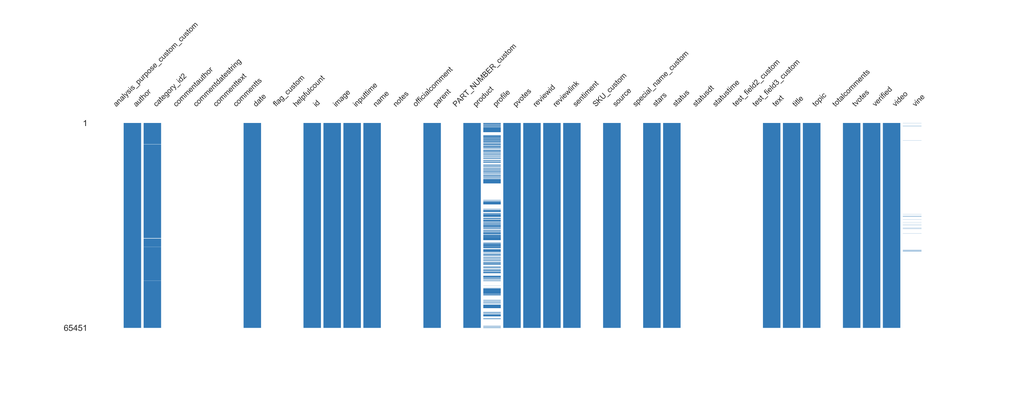

**Heatmap**

[figure not shown]

**Dendrogram**

[figure not shown]

# Sample

## First rows

|  | analysis_purpose_custom_custom | author | category_id2 | commentauthor | commentdatestring | commenttext | commentts | date | flag_custom | helpfulcount | id | image | inputtime | name | notes | officialcomment | parent | PART_NUMBER_custom | product | profile | pvotes | reviewid | reviewlink | sentiment | SKU_custom | source | special_name_custom | stars | status | … |
| --- | --- | --- | --- | --- | --- | --- | --- | --- | --- | --- | --- | --- | --- | --- | --- | --- | --- | --- | --- | --- | --- | --- | --- | --- | --- | --- | --- | --- | --- | --- |
| 0 | NaN | Amazon Customer | pet-supplies | NaN | NaN | NaN | NaN | 2018-12-20 08:00 | NaN | NaN | B078N8NR7G | No | 2018-12-22 06:24 | PetSafe 900 Meter Remote Trainer | NaN | NaN | B078Y3F7MG | NaN | B078N8NR7G | https://www.amazon.ca/gp/profile/amzn1.account.AHXGHQLLRKPURPVJYTWO7I7AB4DA/ref=cm_cr_arp_d_gw_btm?ie=UTF8 | 0 | R31B5G60GS531M | https://www.amazon.ca/review/R31B5G60GS531M/ref=cm_cr_dp_title?ie=UTF8&ASIN=B078N8NR7G | Not Assigned | NaN | amazon.ca | NaN | 1 | Not Assigned | … |
| 1 | NaN | nathalie | pet-supplies | NaN | NaN | NaN | NaN | 2019-04-13 08:00 | NaN | NaN | B01HO8U5NC | No | 2019-04-15 10:32 | Drinkwell Platinum Pet Fountain 168oz | NaN | NaN | B01MQ1JZ3L | NaN | B01HO8U5NC | https://www.amazon.ca/gp/profile/amzn1.account.AHNM2DIYUKF6P6JQOU2KNOKRPEPQ | 0 | RRCY4V48RQBXG | https://www.amazon.ca/review/RRCY4V48RQBXG/ref=cm_cr_dp_title?ie=UTF8&ASIN=B01HO8U5NC | Not Assigned | NaN | amazon.ca | NaN | 5 | Not Assigned | … |
| 2 | NaN | Conure Mum | pet-supplies | NaN | NaN | NaN | NaN | 2019-04-02 08:00 | NaN | NaN | B01HO8U5NC | Yes | 2019-04-04 12:02 | Drinkwell Platinum Pet Fountain 168oz | NaN | NaN | B01MQ1JZ3L | NaN | B01HO8U5NC | https://www.amazon.ca/gp/profile/amzn1.account.AHOEGFFK7INBIPCDO7PKPUTZMRXQ | 0 | R18076F5C879LP | https://www.amazon.ca/review/R18076F5C879LP/ref=cm_cr_dp_title?ie=UTF8&ASIN=B01HO8U5NC | Not Assigned | NaN | amazon.ca | NaN | 4 | Not Assigned | … |
| 3 | NaN | Wayne Smith | pet-supplies | NaN | NaN | NaN | NaN | 2019-03-31 08:00 | NaN | NaN | B01HO8U5NC | No | 2019-04-02 20:35 | Drinkwell Platinum Pet Fountain 168oz | NaN | NaN | B01MQ1JZ3L | NaN | B01HO8U5NC | https://www.amazon.ca/gp/profile/amzn1.account.AGZ476P3EVM6UAENKIUUUYSA4J4A | 0 | RLA1DFN3DCSFJ | https://www.amazon.ca/review/RLA1DFN3DCSFJ/ref=cm_cr_dp_title?ie=UTF8&ASIN=B01HO8U5NC | Not Assigned | NaN | amazon.ca | NaN | 4 | Not Assigned | … |
| 4 | NaN | Rob Self | pet-supplies | NaN | NaN | NaN | NaN | 2018-07-31 08:00 | NaN | NaN | B01HO8U5NC | No | 2018-07-31 08:00 | Drinkwell Platinum Pet Fountain 168oz | NaN | NaN | B01MQ1JZ3L | NaN | B01HO8U5NC | https://www.amazon.ca/gp/profile/amzn1.account.AGHAHXXQGDC6W4B6RGY6D2ILUJPA/ref=cm_cr_arp_d_pdp?ie=UTF8 | 0 | R3F4GS6FDS5ALH | https://www.amazon.ca/review/R3F4GS6FDS5ALH/ref=cm_cr_dp_title?ie=UTF8&ASIN=B01HO8U5NC | Not Assigned | NaN | amazon.ca | NaN | 3 | Not Assigned | … |
| 5 | NaN | Richard Goods | pet-supplies | NaN | NaN | NaN | NaN | 2018-07-29 08:00 | NaN | NaN | B01HO8U5NC | No | 2018-07-29 08:00 | Drinkwell Platinum Pet Fountain 168oz | NaN | NaN | B01MQ1JZ3L | NaN | B01HO8U5NC | https://www.amazon.ca/gp/profile/amzn1.account.AGEIDBVV56UXQVRXJEAZUVZLAAIA/ref=cm_cr_arp_d_pdp?ie=UTF8 | 0 | R1KDTNCKJ3DCV2 | https://www.amazon.ca/review/R1KDTNCKJ3DCV2/ref=cm_cr_dp_title?ie=UTF8&ASIN=B01HO8U5NC | Not Assigned | NaN | amazon.ca | NaN | 5 | Not Assigned | … |
| 6 | NaN | Jerome Tanguay | pet-supplies | NaN | NaN | NaN | NaN | 2018-04-12 08:00 | NaN | NaN | B01HO8U5NC | No | 2018-04-12 08:00 | Drinkwell Platinum Pet Fountain 168oz | NaN | NaN | B01MQ1JZ3L | NaN | B01HO8U5NC | https://www.amazon.ca/gp/profile/amzn1.account.AELNNSQ7AJWS6USZ3H6PBPPBSUOQ/ref=cm_cr_arp_d_pdp?ie=UTF8 | 0 | R10TY9YVK98S85 | https://www.amazon.ca/review/R10TY9YVK98S85/ref=cm_cr_dp_title?ie=UTF8&ASIN=B01HO8U5NC | Not Assigned | NaN | amazon.ca | NaN | 5 | Not Assigned | … |
| 7 | NaN | Tammy Roode | pet-supplies | NaN | NaN | NaN | NaN | 2018-01-21 08:00 | NaN | NaN | B01HO8U5NC | No | 2018-01-22 08:34 | Drinkwell Platinum Pet Fountain 168oz | NaN | NaN | B01MQ1JZ3L | NaN | B01HO8U5NC | https://www.amazon.ca/gp/profile/amzn1.account.AHL63IJNR23UZN3UKHES45H3QURQ/ref=cm_cr_arp_d_pdp?ie=UTF8 | 0 | R1ZRSF0QANSTRY | https://www.amazon.ca/review/R1ZRSF0QANSTRY/ref=cm_cr_dp_title?ie=UTF8&ASIN=B01HO8U5NC | Not Assigned | NaN | amazon.ca | NaN | 5 | Not Assigned | … |
| 8 | NaN | Lisa | pet-supplies | NaN | NaN | NaN | NaN | 2018-01-08 08:00 | NaN | NaN | B01HO8U5NC | No | 2018-01-08 18:43 | Drinkwell Platinum Pet Fountain 168oz | NaN | NaN | B01MQ1JZ3L | NaN | B01HO8U5NC | https://www.amazon.ca/gp/profile/amzn1.account.AESVWPHBGIQHV25TV4KVVRFVOUJA/ref=cm_cr_arp_d_pdp?ie=UTF8 | 0 | R3HA5C606GWKN | https://www.amazon.ca/review/R3HA5C606GWKN/ref=cm_cr_dp_title?ie=UTF8&ASIN=B01HO8U5NC | Not Assigned | NaN | amazon.ca | NaN | 5 | Not Assigned | … |
| 9 | NaN | mika jiang | pet-supplies | NaN | NaN | NaN | NaN | 2017-10-21 08:00 | NaN | NaN | B01HO8U5NC | No | 2017-10-23 06:09 | Drinkwell Platinum Pet Fountain 168oz | NaN | NaN | B01MQ1JZ3L | NaN | B01HO8U5NC | https://www.amazon.ca/gp/profile/amzn1.account.AFMRFPAP2N7DX2LTKCYWNXP6R3FA/ref=cm_cr_arp_d_pdp?ie=UTF8 | 0 | R2OHNULSZ4ARHS | https://www.amazon.ca/review/R2OHNULSZ4ARHS/ref=cm_cr_dp_title?ie=UTF8&ASIN=B01HO8U5NC | Not Assigned | NaN | amazon.ca | NaN | 1 | Not Assigned | … |

## Last rows

|  | analysis_purpose_custom_custom | author | category_id2 | commentauthor | commentdatestring | commenttext | commentts | date | flag_custom | helpfulcount | id | image | inputtime | name | notes | officialcomment | parent | PART_NUMBER_custom | product | profile | pvotes | reviewid | reviewlink | sentiment | SKU_custom | source | special_name_custom | stars | status | … |
| --- | --- | --- | --- | --- | --- | --- | --- | --- | --- | --- | --- | --- | --- | --- | --- | --- | --- | --- | --- | --- | --- | --- | --- | --- | --- | --- | --- | --- | --- | --- |
| 65441 | NaN | Joseanne Lambert | pet-supplies/2975420011 | NaN | NaN | NaN | NaN | 2017-10-21 08:00 | NaN | NaN | B00074L4UO | No | 2017-10-22 05:54 | PetSafe Gentle Leader Headcollar, No-Pull Dog Collar | NaN | NaN | B07XTY7FR9 | NaN | B00074L4UO | https://www.amazon.com/gp/profile/amzn1.account.AG2XQA7LXIP5KGWGSGKWMVZW6VFQ/ref=cm_cr_arp_d_pdp?ie=UTF8 | 0 | R1QZYXTO10479O | https://www.amazon.com/review/R1QZYXTO10479O/ref=cm_cr_dp_title?ie=UTF8&ASIN=B00074L4UO | Not Assigned | NaN | amazon | NaN | 2 | Not Assigned | … |
| 65442 | NaN | J. Beghin | pet-supplies/2975420011 | NaN | NaN | NaN | NaN | 2017-10-21 08:00 | NaN | NaN | B00074L4UO | No | 2017-10-21 21:46 | PetSafe Gentle Leader Headcollar, No-Pull Dog Collar | NaN | NaN | B07XTY7FR9 | NaN | B00074L4UO | https://www.amazon.com/gp/profile/amzn1.account.AEOXYEPDEL4VZN77PUJ2223KBFJQ/ref=cm_cr_arp_d_pdp?ie=UTF8 | 0 | RWH8GLM49VAI8 | https://www.amazon.com/review/RWH8GLM49VAI8/ref=cm_cr_dp_title?ie=UTF8&ASIN=B00074L4UO | Not Assigned | NaN | amazon | NaN | 5 | Not Assigned | … |
| 65443 | NaN | Alison Thomas | pet-supplies/2975420011 | NaN | NaN | NaN | NaN | 2017-10-18 08:00 | NaN | NaN | B00074L4UO | No | 2017-10-18 22:41 | PetSafe Gentle Leader Headcollar, No-Pull Dog Collar | NaN | NaN | B07XTY7FR9 | NaN | B00074L4UO | https://www.amazon.com/gp/profile/amzn1.account.AFYKYX5KEJF2ZLPY6JOPGNVGSXKQ/ref=cm_cr_arp_d_pdp?ie=UTF8 | 0 | R1VRV7SSOEC4HH | https://www.amazon.com/review/R1VRV7SSOEC4HH/ref=cm_cr_dp_title?ie=UTF8&ASIN=B00074L4UO | Not Assigned | NaN | amazon | NaN | 1 | Not Assigned | … |
| 65444 | NaN | Kindle Customer | pet-supplies/2975420011 | NaN | NaN | NaN | NaN | 2017-10-16 08:00 | NaN | NaN | B00074L4UO | No | 2017-10-16 19:53 | PetSafe Gentle Leader Headcollar, No-Pull Dog Collar | NaN | NaN | B07XTY7FR9 | NaN | B00074L4UO | https://www.amazon.com/gp/profile/amzn1.account.AGJ5M2QL3HJVF4EZDZ2MPTKZVHDQ/ref=cm_cr_arp_d_pdp?ie=UTF8 | 0 | R87VVP7OHZDXH | https://www.amazon.com/review/R87VVP7OHZDXH/ref=cm_cr_dp_title?ie=UTF8&ASIN=B00074L4UO | Not Assigned | NaN | amazon | NaN | 2 | Not Assigned | … |
| 65445 | NaN | kdavis | pet-supplies/2975420011 | NaN | NaN | NaN | NaN | 2017-10-16 08:00 | NaN | NaN | B00074L4UO | No | 2017-10-16 19:53 | PetSafe Gentle Leader Headcollar, No-Pull Dog Collar | NaN | NaN | B07XTY7FR9 | NaN | B00074L4UO | https://www.amazon.com/gp/profile/amzn1.account.AHHU5FWVTC7R3KLWB4DX3Q22JLFQ/ref=cm_cr_arp_d_pdp?ie=UTF8 | 0 | R30CGZXKFAO752 | https://www.amazon.com/review/R30CGZXKFAO752/ref=cm_cr_dp_title?ie=UTF8&ASIN=B00074L4UO | Not Assigned | NaN | amazon | NaN | 3 | Not Assigned | … |
| 65446 | NaN | Mommyof5 | pet-supplies/2975420011 | NaN | NaN | NaN | NaN | 2017-10-05 08:00 | NaN | NaN | B00074L4UO | No | 2017-10-06 12:01 | PetSafe Gentle Leader Headcollar, No-Pull Dog Collar | NaN | NaN | B07XTY7FR9 | NaN | B00074L4UO | https://www.amazon.com/gp/profile/amzn1.account.AF63VS3N7JZIEO5RR5NYKYFQFFPQ/ref=cm_cr_arp_d_pdp?ie=UTF8 | 0 | R39BV18FYPW2QR | https://www.amazon.com/review/R39BV18FYPW2QR/ref=cm_cr_dp_title?ie=UTF8&ASIN=B00074L4UO | Not Assigned | NaN | amazon | NaN | 4 | Not Assigned | … |
| 65447 | NaN | Alan S. carlson | pet-supplies/2975420011 | NaN | NaN | NaN | NaN | 2017-09-26 08:00 | NaN | NaN | B00074L4UO | No | 2017-09-27 04:45 | PetSafe Gentle Leader Headcollar, No-Pull Dog Collar | NaN | NaN | B07XTY7FR9 | NaN | B00074L4UO | https://www.amazon.com/gp/profile/amzn1.account.AF7B6HIQDG6NXBEZGKDNKT7ZA2CQ/ref=cm_cr_arp_d_pdp?ie=UTF8 | 0 | R3SNHNU4DZAL4Z | https://www.amazon.com/review/R3SNHNU4DZAL4Z/ref=cm_cr_dp_title?ie=UTF8&ASIN=B00074L4UO | Not Assigned | NaN | amazon | NaN | 5 | Not Assigned | … |
| 65448 | NaN | @TANDATravels | pet-supplies/2975420011 | NaN | NaN | NaN | NaN | 2017-09-23 08:00 | NaN | NaN | B00074L4UO | Yes | 2017-09-24 01:11 | PetSafe Gentle Leader Headcollar, No-Pull Dog Collar | NaN | NaN | B07XTY7FR9 | NaN | B00074L4UO | https://www.amazon.com/gp/profile/amzn1.account.AEEQUH6PC2KWF62G3L3DVJ2DFOWQ/ref=cm_cr_arp_d_pdp?ie=UTF8 | 0 | RPVPJNLZ99DMC | https://www.amazon.com/review/RPVPJNLZ99DMC/ref=cm_cr_dp_title?ie=UTF8&ASIN=B00074L4UO | Not Assigned | NaN | amazon | NaN | 5 | Not Assigned | … |
| 65449 | NaN | marcie | pet-supplies/2975420011 | NaN | NaN | NaN | NaN | 2017-09-16 08:00 | NaN | NaN | B00074L4UO | No | 2017-09-17 00:51 | PetSafe Gentle Leader Headcollar, No-Pull Dog Collar | NaN | NaN | B07XTY7FR9 | NaN | B00074L4UO | https://www.amazon.com/gp/profile/amzn1.account.AFH2HSO4EWOBLYGW5NAYOERDFJ7Q/ref=cm_cr_arp_d_pdp?ie=UTF8 | 0 | R1GOGZGVL6EEZQ | https://www.amazon.com/review/R1GOGZGVL6EEZQ/ref=cm_cr_dp_title?ie=UTF8&ASIN=B00074L4UO | Not Assigned | NaN | amazon | NaN | 5 | Not Assigned | … |
| 65450 | NaN | Shelon Surat | pet-supplies/2975420011 | NaN | NaN | NaN | NaN | 2017-09-15 08:00 | NaN | NaN | B00074L4UO | No | 2017-09-15 09:44 | PetSafe Gentle Leader Headcollar, No-Pull Dog Collar | NaN | NaN | B07XTY7FR9 | NaN | B00074L4UO | https://www.amazon.com/gp/profile/amzn1.account.AE2BCKUZBDMDOZHK2WEYG6QME23Q/ref=cm_cr_arp_d_pdp?ie=UTF8 | 0 | R3UJ8C5LRVV5C5 | https://www.amazon.com/review/R3UJ8C5LRVV5C5/ref=cm_cr_dp_title?ie=UTF8&ASIN=B00074L4UO | Not Assigned | NaN | amazon | NaN | 5 | Not Assigned | … |